# Assignment 3

Felix Su

February 1, 2016

*Source file* ⇒ ~/ucb_classes/Sp16/STAT133/hw/hw3/Assignment-Three-Su.Rmd

### Monday Assignment

**Problem 5.4**

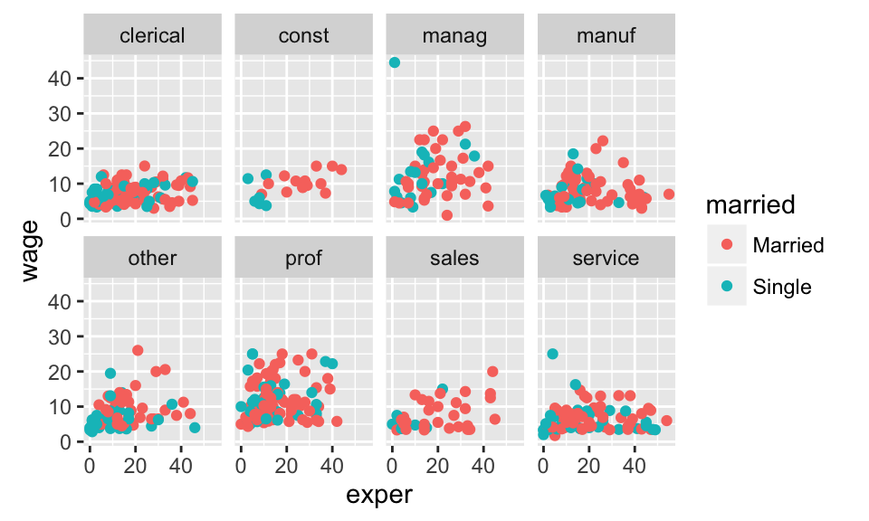

```r
ggplot(data=CPS85,aes(x=exper,y=wage))+geom_point()+aes(colour=married)+facet_wrap(~sector,ncol=4)
```

**Problem 6.3**

**Problem 6.6**

In Figure 6.9, what is the glyph and its graphical attributes?

- **Glyph: Rectangle. Graphical attribute: color and text.**

**Problem 6.8**

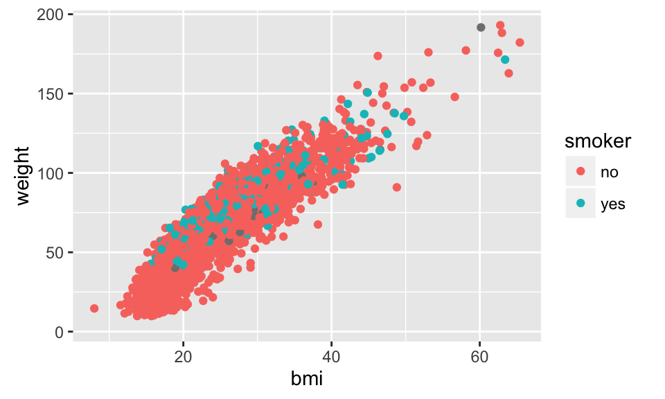

```r
Small <- NCHS %>% sample_n(size=5000)
ggplot(data=Small,aes(x=bmi,y=weight))+geom_point()+aes(colour=smoker)
```

Write down the mapping between variables and graphical attributes.

### Wednesday Assignment

**Problem 6.2**

1. List all of the guides in the graph. For each one, say which variable is being mapped to which graphical attribute.
   - **x-axis tick marks**
     - **gene label: x position**
   - **y-axis tick marks**
     - **Log enyzme concentration: y position**
   - **target sections**
     - **target type: x position**
   - **Molecule guide**
     - **molecule type: color**
   - **Flux guide**
     - **positive flux: filled glyph**
     - **0 flux: outline glyph**
2. The basic glyph is a dot. Say what are the graphical attributes of the dot (e.g. color, size, …). For each graphical attribute found in the graph, say which variable is mapped to that attribute.
   - **position**
     - **x position: gene label and target type**
     - **y position: Log enyzme concentration**
   - **color**
     - **molecule type**
   - **fill**
     - **filled: positive flux**
     - **outline: 0 flux**
3. Which two variables set the frame?
   - **x = gene label**
   - **y = Log enyzme concentration**
4. The scaling of the horizontal variable (e.g.the translation of position to variable levels) is set by a combination of two variables. Which two?
   - **gene label**
   - **target type**

**Problem 7.2**

1. Which color diamonds seem to be largest on average (in terms of carats)?
   - **Diamonds with color “J” (worst) seem to be the largest on average (in terms of carats)**

```r
diamonds %>%
  group_by(color) %>%
  summarise(size = mean(carat)) %>%
  arrange(desc( size )) %>%
  head( 1 )
```

```
## Source: local data frame [1 x 2]
##
##    color     size
##   (fctr)    (dbl)
## 1      J 1.162137
```

2. Which clarity of diamonds has the largest average “table” per carat?
   - **Diamonds with clarity “VVS1” seem to have the largest average “table” per carat**

```r
diamonds %>%
  group_by(clarity) %>%
  summarise(tbl_per_carat = mean(table/carat)) %>%
  arrange(desc( tbl_per_carat )) %>%
  head( 1 )
```

```
## Source: local data frame [1 x 2]
##
##   clarity tbl_per_carat
##    (fctr)         (dbl)
## 1    VVS1      141.4822
```

**Problem 7.4** Each of these statements have an error. It might be an error in syntax or an error in the way the data tables are used, etc. Tell what are the error(s) in these expressions.

1. `BabyNames %>% group_by( "First" ) %>% summarise( votesReceived=n() )`
   - **Error: trying to get votesReceived from the wrong table. Number of cases in BabyNames does not reflect meaningful data on any kind of voting.**
2. `Tmp <- group_by(BabyNames, year, sex ) %>% summarise( Tmp, totalBirths=sum(count))`
   - **Error: Trying to bind data table Tmp to summarise, but it has not been declared yet. It should be removed because BabyNames will be piped in. Also, because BabyNames is piped in, this function will try to use Tmp as a variable binding, which will cause an error.**
3. `Tmp <- group_by(BabyNames, year, sex) summarise( BabyNames, totalBirths=sum(count) )`
   - **Error: Missing a piping symbol. This will cause an ‘unexpected’ symbol error because R does not understand the connection between group_by and summarise. Note: Can also use nesting if so desired.**

**Problem 7.5** For each of the following outputs, identify the operation linking the input to the output and write down the details (i.e., arguments) of the operation.

2. Output Table B
   - **Variables: sex**
   - **Verbs: group_by**
   - **Operation:**

     ```
     Input %>%
       group_by(sex)
     ```

3. Output Table C
   - **Variables: name, sex**
   - **Verbs: group_by, arrange**
   - **Operation:**

     ```
     Input %>%
       group_by(name, sex) %>%
       arrange(name)
     ```

4. Output Table D
   - **Variables: count**
   - **Verbs: summarize, sum**
   - **Operation:**

     ```
     Input %>%
       summarise(total = sum(count)) %>%
     ```

5. Output Table E
   - **Variables: name, count**
   - **Verbs: group_by, select**
   - **Operation:**

     ```
     Input %>%
       group_by(name) %>%
       select(name, count)
     ```

**Problem 7.6**

1. How many cases are there?
   - **80101 cases**
2. Who were the top 5 candidates in the Second vote selections.

```r
Minneapolis2013 %>%
  group_by(Second) %>%
  summarise(sec_vote = n()) %>%
  arrange(desc(sec_vote)) %>%
  head(6)
```

```
## Source: local data frame [6 x 2]
##
##               Second sec_vote
##                (chr)    (int)
## 1       BETSY HODGES    14399
## 2        DON SAMUELS    14170
## 3        MARK ANDREW    12757
## 4          undervote    10598
## 5 JACKIE CHERRYHOMES     6470
## 6           BOB FINE     3751
```

```
+ 1) Betsey Hodges, 2) Don Samuels, 3) Mark Andrew, 4) Jackie Cherryhomes, 5) Bob Fine
+ Note: Does not include "undervote"
```

3. How many ballots are marked “undervote” in
   - First choice selections: **834 undervotes**
   - Second choice selections: **10598 undervotes**
   - Third choice selections: **19210 undervotes**

```r
Minneapolis2013 %>%
  summarise(count = sum(First == "undervote"))
```

```
##   count
## 1   834
```

```r
Minneapolis2013 %>%
  summarise(count = sum(Second == "undervote"))
```

```
##   count
## 1 10598
```

```r
Minneapolis2013 %>%
  summarise(count = sum(Third == "undervote"))
```

```
##   count
## 1 19210
```

4. What are the top 3 combinations of First and Second vote selections? (That is, of all the possible ways a voter might have marked his or her first and second choices, which received the highest number of votes?)

```r
Minneapolis2013 %>%
  group_by(First, Second) %>%
  summarise(count = n()) %>%
  filter(count > 6000) %>%
  arrange(desc(count))
```

```
## Source: local data frame [3 x 3]
## Groups: First [2]
##
##          First       Second count
##          (chr)        (chr) (int)
## 1 BETSY HODGES  MARK ANDREW  8787
## 2 BETSY HODGES  DON SAMUELS  8743
## 3  MARK ANDREW BETSY HODGES  6970
```

```
+ **1) Betsy Hodges, Mark Andrew**
+ **2) Betsy Hodges, Don Samuels**
+ **3) Mark Andrew, Betsy Hodges**
```

5. Which Precinct had the highest number of ballots cast?
   - **P-06 had the highest amount of ballots cast at 9711**

```r
Minneapolis2013 %>%
  group_by(Precinct) %>%
  summarise(count = n()) %>%
  arrange(desc(count)) %>%
  head(1)
```

```
## Source: local data frame [1 x 2]
##
##   Precinct count
##      (chr) (int)
## 1     P-06  9711
```

**Problem 8.1** Match each of the functions to the task it performs.

1. geom_point()
   - **2) Add a layer of glyphs**
2. geom_histogram()
   - **2) Add a layer of glyphs**
3. ggplot()
   - **1) Construct the graphics frame**
4. scale_y_log10()
   - **5) Change the scale for the frame.**
5. ylab()
   - **3) Set an axis label**
6. facet_wrap()
   - **4) Divide the frame into facets**
7. geom_segment()
   - **2) Add a layer of glyphs**
8. xlim()
   - **5) Change the scale for the frame.**
9. facet_grid()
   - **4) Divide the frame into facets**

**Problem 8.2** Here are two more graphics based on the mosaicData::CPS85 data table. Write ggplot2() statements that will construct each graphic.

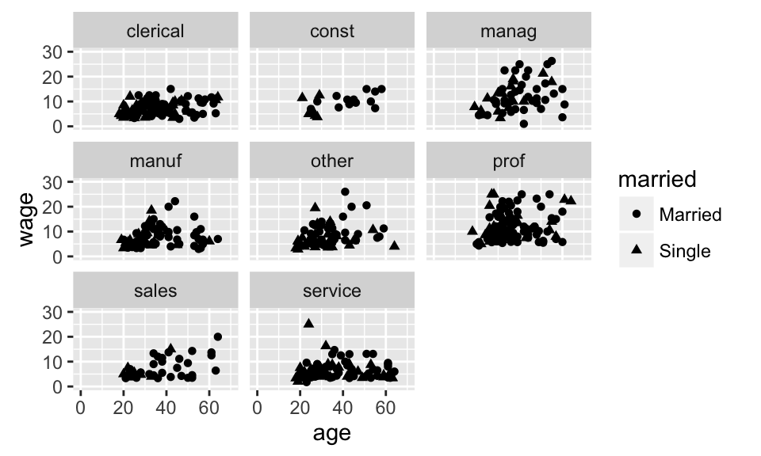

```r
ggplot(CPS85,aes(x=age,y=wage,shape=married)) +
  facet_wrap( ~ sector) +
  xlim(0, 70) + ylim(0, 30) +
  geom_point()
```

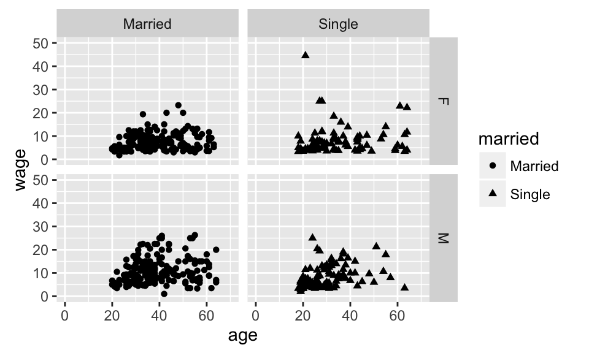

```r
ggplot(CPS85,aes(x=age,y=wage,shape=married)) +
  facet_grid(sex ~ married) +
  xlim(0, 70) + ylim(0, 50) +
  geom_point()
```